# 從競爭優勢到基本能力

> 程式設計與資料分析

郭耀仁 yaojenkuo@ntu.edu.tw | 2024-11-22

## 關於講者：郭耀仁

- 資料科學的專業講師，在 [Hahow 好學校](https://hahow.in/@tonykuoyj?tr=tonykuoyj) 開設六堂線上課程，共有六千多名學生。
- 實體課程有台大工商管理學系與台大共同教育中心的三學分必修課、選修課，與台大資工系統訓練班、中華電信學院長期合作開設資料科學課程。
- 講授過星展銀行、華南銀行與玉山銀行的 Python 工作坊。
- 在擔任專業講師前曾於酷澎（Coupang）、賽仕電腦（SAS）與中國信託（CTBC）任職；畢業自台灣大學商學研究所。
- 閒暇時喜歡長跑與桌球。

[figure not shown]

## 緣起：2012 年的哈佛商業評論

[figure not shown]

來源：https://hbr.org/2012/10/data-scientist-the-sexiest-job-of-the-21st-century

## Data science 旋風從加州矽谷刮向全世界的 12 年

- 從 business intelligence、big data、machine learning、deep learning 到 artificial intelligence
- 從百花齊放的科學計算語言（Matlab/SAS/R/Python/Scala/Julia）到 Python 獨霸一方。
- 解決方案廠商的銷售主力從資料庫管理系統、Hadoop/Spark、商業智慧軟體、統計分析軟體（SPSS/Minitab）再到開源兼容平台。

## Data science 旋風從加州矽谷刮向全世界的 12 年（續）

- 主修 Data science 的碩士學位如雨後春筍，除了學位，亦有學程、組別或模組的設計。
- 非資訊相關學院例如社科學院、商管學院也都投注資源。
  - 台大經濟系：資料科學與社會研究跨域學程。
  - 台大工管系：營運與商業數據分析模組。
  - 台大資管系：商管程式設計。
  - 台大共教中心：程式設計與網路資料搜集、用 Python 與 Excel 學習統計模型思維、程式設計與資料分析。
- 社團經營：台大資料分析社、成大資料分析社、政大資料分析社、清大資料分析社...etc.

## Data science 旋風從加州矽谷刮向全世界的 12 年（續）

- 我開的課程：
  - 視覺化與現代資料科學（2024 Spring）：409 位同學選修。
  - 程式設計與資料分析（2023 Fall）：202 位同學選修。

## 程式設計與資料分析的能力成為畢業生、轉職者的競爭優勢

> 今年即將畢業的廖OO，去年進入微軟實習，因為表現優異而獲得正職。

> 經濟系訓練的另一個特色，是一步步拆解問題、到可用資料回答的問題界定能力。在知名音樂平台KKbox工作的陳OO，就是一例

> 拿到美國波士頓大學經濟碩士後，彭OO曾在台灣惠普做過2年供應鏈分析師，工作閒暇之餘，參加了台大資工系統訓練班，開始有系統地學寫程式。

來源：[微軟、Uber都愛用 台大這個系為何是大數據人才搖籃？](https://www.cw.com.tw/article/5095753)

## 現在進入職場的新人很有可能是三棲型人才

- 領域知識（科系、主修、輔系）。
- 程式設計。
- 資料分析（統計、機器學習、演算法）。

來源：http://drewconway.com/zia/2013/3/26/the-data-science-venn-diagram

## 未來進入職場的新人

我大膽預測，未來進入職場的新人很有可能將不再具備程式設計與資料分析的競爭優勢，而是像商業英文（全民英檢中高級、TOEIC）、辦公室軟體（文書處理、簡報設計、試算表運算）成為基礎能力之一。

[figure not shown]

## 資料分析通識

## 三個重點

1. 分析有兩種：商業導向與資料導向。
2. 「沒有」一個泛用的分析框架可以套用在所有的專案中。
3. 黑羊白羊過橋，無論商業導向或資料導向，總要有一方讓步。

## 什麼是分析

- 將某個有興趣的問題拆分為數個小問題。
- 研究小問題與有興趣的問題之間的關係。

## 能簡短說明何謂「資料分析」嗎

撇除所有華麗的詞彙，「資料分析」是透過以邏輯、事實以及量化為基準來解決問題的方法。

## 為什麼要透過資料分析解決問題

分析是連接問題與行動計畫之間的橋樑。

- 問題。
- 資料分析。
- 行動計畫。
- 評估。
- ...重複循環。

## 不同導向的分析

- **資料導向的分析**。
- **商業導向的分析**。
- 報酬導向的分析。
- 財報導向的分析。
- 交易導向的分析。
- ...等。

## 因應而生的分析框架

- 增進分析的效率、品質、可靠性與強韌性。
- 實踐 DRY(Don’t Repeat Yourself)準則。

## 太多的分析框架

[figure not shown]

來源：http://gph.is/18hNtOr

## 商業導向的分析師

- 常春藤系統（3Cs、4Ps、波特五力）
- 企管顧問公司系統（BCG 矩陣、麥肯錫七步驟）
- 損益表分析。
- ...等。

## 資料導向的分析師

- Gartner 分析遞增模型。
- 資料科學金字塔需求。
- 資料科學專案流程。
- ...等。

## 什麼是常春藤系統（3Cs、4Ps、波特五力）

- Customer/Competitor/Company
- Product/Price/Place/Promotion
- 既有競爭者、潛在新進者、供應商議價力、消費者議價力、替代品威脅。

## 什麼是企管顧問公司系統（BCG 矩陣）

[figure not shown]

來源：https://www.bcg.com/about/overview/our-history/growth-share-matrix

## 什麼是企管顧問公司系統（麥肯錫七步驟）

1. 問題定義。
2. 問題解構。
3. 排序順位。
4. 議題分析。
5. 整合。
6. 故事力。
7. 簡報。

...重複循環。

## 什麼是 Gartner 分析遞增模型

[figure not shown]

來源：https://www.gartner.com/en/documents/1964015/best-practices-in-analytics-integrating-analytical-capab

## 什麼是資料科學金字塔需求

[figure not shown]

來源：https://hackernoon.com/the-ai-hierarchy-of-needs-18f111fcc007

## 什麼是資料科學專案流程

[figure not shown]

來源：https://r4ds.had.co.nz/introduction.html

## 不同的專注

- 商業導向專注在推論邏輯。
- 資料導向專注在資訊價值。

## 小結

- 談論到「分析」的時候會產生一定程度的混淆，特別是多樣化的專業背景。
- 我們談到了兩種導向的分析：商業導向與資料導向。
- 不論商業導向或資料導向，都有多樣化的框架。

## 童話故事

有一個泛用的分析框架可以套用在所有的專案中。

## 挑選適當的預測器

[figure not shown]

來源：https://scikit-learn.org/stable/tutorial/machine_learning_map/index.html

## 挑選適當的推論

[figure not shown]

來源：https://coggle.it/diagram/Vxlydu1akQFeqo6-/t/inference

## 有許多的模型、框架

- 我們沒有自信說哪個模型是「最棒」的，但我們或許能夠說在手邊可取得的模型中有一個最合適的。
- 我們同樣沒有自信說哪個框架可以「一體適用」，但我們或許能夠說某些框架是比較泛用的。

## 泛用程度較高的商業導向分析框架

1. 問題定義。
2. 問題解構。
3. 排序順位。
4. 整合。

...重複循環。

## 好的問題定義

- 具體。
- 可討論。
- 將問題連結到決策者。

## 問題解構的核心

> There is only one way to eat an elephant: a bite at a time.

> Desmond Tutu

## 好的問題解構

- 邏輯樹。
  - 議題樹。
  - 假說推論樹。
- M.E.C.E. 互斥且周延法則。

## 議題樹：前向推導

- 如何存更多錢？
  - 增加收入。
    - 賺取業務獎金。
    - 賺取加班費。
    - 調整投資組合。
  - 減少支出。
    - 換季折扣。
    - 快時尚。
    - 現金回饋。

## 假說推論樹：後向推導

- 我可以透過調整投資組合來存更多錢。
  - 我不是從事業務性質工作。
  - 我不想改變消費習慣。
  - 我目前的投資策略過於保守。
    - 減少指數投資、增加個股投資。
    - 透過借貸增加報酬率。
    - 增加波段操作。

## 好的排序順位

- 同時考量財務效果與導入難易度。
- 建立財務效果難易矩陣。

來源：[Ten red flags signaling your analytics program will fail](https://www.mckinsey.com/business-functions/mckinsey-analytics/our-insights/ten-red-flags-signaling-your-analytics-program-will-fail)

## 好的整合

- 連結假說與支持論述。
- 標記必須的資訊。
- 辨認責任與時間表。

## 泛用程度較高的資料導向分析框架

- 透過程式設計完成：
  - 載入資料。
  - 清理資料。
  - 轉換資料。
  - 資料視覺化。
  - 建立模型。
  - 溝通。

來源：https://r4ds.had.co.nz/introduction.html

## 泛用程度較高的資料導向分析框架（續）

[figure not shown]

來源：https://r4ds.had.co.nz/introduction.html

## 為什麼要透過 Program 完成六個應用場景

- 自動化。
- 規模化。

## 很多程式語言都可以完成這六個應用場景

- Python
- R
- Julia
- Scala
- Matlab
- SAS
- ...等。

## 如何選擇合適的程式語言

- 西瓜理論。
- 科學計算的支援性。
- 程式語言的特性。

## 西瓜理論

夏日炎炎，晚餐後的水果是西瓜，如何選擇餐桌上的西瓜？

來源：https://trends.stackoverflow.co/?tags=python,r,sas,matlab,julia,scala

## 西瓜理論（續）

> Python is becoming the world’s most popular coding language.

> [The Economist, 2018-07-26](https://www.economist.com/graphic-detail/2018/07/26/python-is-becoming-the-worlds-most-popular-coding-language)

## Python 程式語言是目前的當紅炸子雞

[Most Popular Programming Languages - 1965/2024](https://youtu.be/xOW3Cehg_qg?si=mQLv5vI_Z7kW2xKg)

## 科學計算的支援性

- 是否支援向量、矩陣與張量計算？
- 是否支援結構化、非結構化資料？
- 是否支援視覺化？

## 程式語言的特性

- 靜態或動態型別。
- 專用或泛用程式語言。
- 函數型或物件導向型設計。

## 小結

- 沒有一個最棒的框架來解決所有的分析問題，但可能有比較能廣泛適用多數問題的框架。
- 資料科學專案指的是透過程式設計完成六個應用場景。

## BE WATER MY FRIEND

> Be formless, shapeless, like water.

> Bruce Lee

來源：https://youtu.be/uk1lzkH-e4U?t=947

## 混成分析框架

- 「商業導向」的分析框架 +「資料導向」的分析框架。
  - 定義問題。
  - 解構問題。
  - 建構假說。
  - 排序順位。
  - 資料科學專案。
  - 整合。
  - 溝通。

## 好的資料分析師

- 對資訊科技感到飢渴。
- 對商業模式感到興趣。

## 由資料導向的分析師弭平差距

- 在問題定義的環節更用功。
- 掌握排序順位與整合。
- 在溝通的環節更用功。

## 在問題定義的環節更用功

- 快速辨識決策者、參與者與自己的共同利益。
- 視參與者為同伴，盡量避免帶著過強的防衛心。
- 熱情地、高參與度地、客觀地並帶著能夠被指導的心態。

## 如何掌握問題定義：YOU HAVE GOT TO LISTEN

[figure not shown]

來源：https://gph.is/g/EGyoXQ3

## 掌握排序順位與整合

- 從混淆矩陣邁向成本效益矩陣。
- 掌握 80/20 法則。
- 藉由整合責任、時間表與具體步驟創造有效的行動方案。

## 成本效益矩陣

[figure not shown]

來源：https://www.amazon.com/Data-Science-Business-Data-Analytic-Thinking/dp/1449361323

## 在溝通的環節更用功

- 將邏輯保留至成最後一個大招。
- 準備兩個額外的選項。

## 說服的藝術：亞里斯多德框架

- 情感 Pathos
- 信譽 Ethos
- 邏輯 Logos

## 準備兩個額外的選項

- 第一好。
- **第二好**：把自己最希望決策者挑選的放在這。
- 第三好。

## 小結

- 使用混成框架。
- 分析師該如何弭平差距的訣竅。

## 程式設計與資料分析範例：如何成為資料分析師？

## 定義「資料分析師」

能夠透過以邏輯、事實以及量化指標為基準來解決問題的人士。

## 技能供給與職缺需求的交點

- 技能供給，資料科學的問卷調查。
- 職缺需求，徵才網站的職缺描述。

## 資料分析師的技能供給

- 主要工作內容。
- 使用程式語言。
- 視覺化框架。
- 商業智能軟體。
- 機器學習框架。
- 關聯式資料庫。

來源：https://www.kaggle.com/c/kaggle-survey-2022

```python
from ks2022 import KaggleSurvey2022

kaggle_survey = KaggleSurvey2022("kaggle_survey_2022_responses.csv")
```

## 主要工作內容

> Select any activities that make up an important part of your role at work: (Select all that apply)

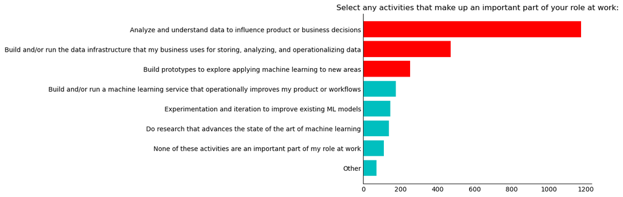

```python
kaggle_survey.plot_survey_summary("Q28")
```

## 使用程式語言

> What programming languages do you use on a regular basis? (Select all that apply)

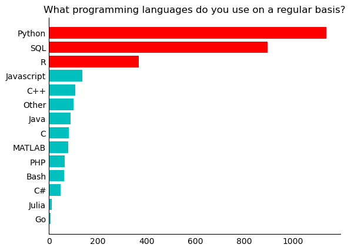

```python
kaggle_survey.plot_survey_summary("Q12")
```

## 視覺化框架

> What data visualization libraries or tools do you use on a regular basis? (Select all that apply)

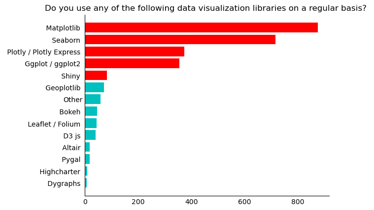

```python
kaggle_survey.plot_survey_summary("Q15", n=5)
```

## 商業智能軟體

> Which of the following business intelligence tools do you use on a regular basis? (Select all that apply)

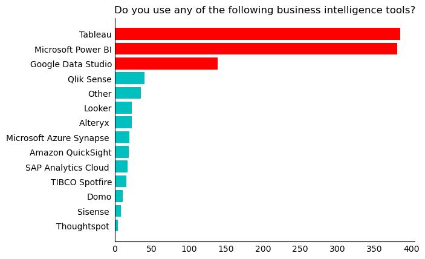

```python
kaggle_survey.plot_survey_summary("Q36")
```

## 機器學習框架

> Which of the following machine learning frameworks do you use on a regular basis? (Select all that apply)

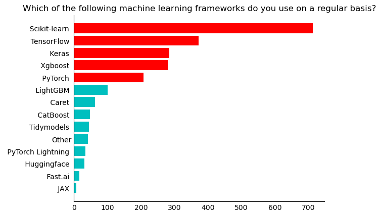

```python
kaggle_survey.plot_survey_summary("Q17", n=5)
```

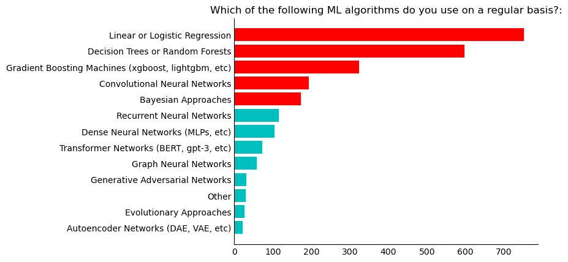

```python
kaggle_survey.plot_survey_summary("Q18", n=5)
```

## 關聯式資料庫

> Which of the following big data products (relational databases, data warehouses, data lakes, or similar) do you use on a regular basis? (Select all that apply)

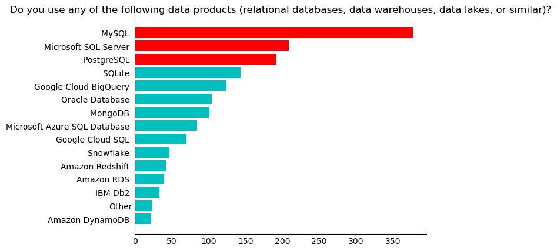

```python
kaggle_survey.plot_survey_summary("Q35")
```

## 蒐集資料分析師的職缺需求

- [Indeed](https://tw.indeed.com/?r=us)
- [CakeResume](https://www.cakeresume.com/jobs)
- [104 人力銀行](https://www.104.com.tw/jobs/main/)
- [Yourator](https://www.yourator.co/)

## 資料分析師的主要工作內容

分析與暸解資料進而影響產品或商業上的決策。

## 資料分析師使用的程式語言

主要使用 Python、SQL 與 R

## 資料分析師的視覺化套件

主要使用的視覺化套件是在 Python 使用 matplotlib、seaborn 與 plotly，在 R 使用 ggplot2 與 plotly

## 資料分析師的商業智能軟體

主要使用的商業智能軟體是 Tableau 與 PowerBI

## 資料分析師的機器學習框架

- 主要使用的機器學習框架是 Scikit-Learn 以及深度學習 TensorFlow、Keras、PyTorch
- 主要使用的模型是迴歸、羅吉斯迴歸、決策樹與隨機森林、XGBoost 以及 Deep Learning

## 資料分析師的關聯式資料庫管理系統

主要使用的關聯式資料庫管理系統為 MySQL、PostgreSQL 與 MS SQL Server

## 關於我的大膽預測

> 未來程式設計與資料分析將不再是競爭優勢，而是繼商業英文、辦公室軟體後成為辦公室白領的基礎能力。

## 為什麼我這樣預期

- 十年有成，資料科學與數據分析從時髦術語變為了人盡皆知的學科。
- 線上課程平台成為年輕人學習的主要管道之一，從美國的 Coursera、Udemy 再到台灣的 Hahow、知識衛星等。
- 學習程式設計與資料分析的門檻在大型語言模型的推波助瀾之下更進一步降低。

## 學習程式設計與資料分析 1.0

- 官方文件。
- 技術書籍。
- 就業轉職培訓班（Bootcamp）

## 學習程式設計與資料分析 2.0

- 論壇，例如 StackOverflow/Reddit/Quora
- 部落格。
- 線上課程。
- YouTube
- 雲端環境與測驗批改，例如 Codecademy/LeetCode/CodeWars/HackerRank

## 學習程式設計與資料分析 3.0

- 大型語言模型。
- AI 輔助寫程式編輯器，例如 Copilot/Cursor

## 如何學習程式設計與資料分析

- 掌握核心觀念，理解語意、程式與電腦三者之間的溝通流程。
- 捋袖揎拳，基於練習題（exercise-based）、基於專案（project-based）
- 在生活與工作中應用。

## 我是如何實踐

- 基於練習題：
  - [SQL 的五十道練習](https://hahow.in/cr/sqlfifty)
  - [Python 的 50+ 練習](https://hahow.in/cr/pythonfiftyplus)
  - [R 語言的 50+ 練習](https://hahow.in/cr/rfiftyplus)
  - [進階 SQL 的五十道練習](https://hahow.in/cr/sqlfiftyplus)
  - 程式設計與資料分析：作業 80 / 期中期末考 20。
  - 視覺化與現代資料科學：作業 80 / 期中期末考 20。
- 基於專案：
  - [資料分析的七個練習專案](https://hahow.in/cr/portfolio)

來源：https://hahow.in/@tonykuoyj?tr=tonykuoyj

## 大型語言模型與 AI 輔助寫程式編輯器的威力強大

- 利用 C, C++, Java, JavaScript 與 Python 挑戰 728 題 LeetCode 題目。
- 在簡單、中階與難的題型分別答對 89%, 71% 與 40%

來源：https://ieeexplore.ieee.org/document/10507163

## 為什麼 AI 這麼擅長寫程式

- 測驗批改著重的是輸入與輸出的映射關係。
- 許多訓練資料本身就包含豐富的說明文件（documentation string）。
- 討論程式語言的論壇會針對程式碼部分給予格式（code chunks）。
- GitHub/GitLab 等版本控制、CI/CD 服務有極為豐富的公開 repositories

## AI 短中期發展仍然強勢

- 大型科技公司 Microsoft, Meta, Alphabet, Amazon 在 2024 年上半年的 AI 資本支出總計約 1 千億美金， 比 2023 年上半年多出 47%
- OpenAI 的 GPT-4 訓練成本為 7 千萬美元。
- Meta 的 Llama 2 70B 訓練成本為 4 百萬美元。
- Alphabet 的 Gemini Ultra 訓練成本為 2 億美元。

來源：https://www.forbes.com/sites/bethkindig/2024/08/08/microsoft-leads-big-tech-in-ai-monetization-amazon-a-close-second, https://aiindex.stanford.edu/report

## 大型科技公司 CEO 怎麼説

> "I’d rather build capacity before it is needed rather than too late."

> "Part of what’s important about A.I. is that it can be used to improve all of our products in almost every way."

> Mark Zuckerberg

來源：https://www.nytimes.com/2024/07/31/technology/meta-earnings-artificial-intelligence.html

## 大型科技公司 CEO 怎麼説（續）

[figure not shown]

來源：https://x.com/elonmusk/status/1784561310883344542

## 大型科技公司 CEO 怎麼説（續）

> "Whether we burn 500 million a year or 5 billion or 50 billion a year I don’t care, I genuinely don’t."

> "As long as we can figure out a way to pay the bills, we’re making AGI. It’s going to be expensive."

> Sam Altman

來源：https://finance.yahoo.com/news/openai-sam-altman-doesn-t-161126520.html

## 為什麼我這樣預期 IMHO

- 在甲方從事過 retention 模型在乙方從事過銀行/零售業的 LGD 模型、視覺化儀表板、資料市集的建置專案。
- Tech stack 從 SAS 到 R 再到 Python
- 在校園講課與在企業做教育訓練。
- 一將功成萬骨枯：
  - 一將功成：Microsoft Excel
  - 萬骨枯：主打 no-code/low-code 的解決方案。

## 除了寫程式以外的事

> "If you don't have someone who actually understands the business, understands the strategy, helping you work on the right things rather than the wrong things, chances are you won’t be very impactful."

> Cassie Kozyrkov, Google’s first Chief Decision Scientist

## 自己寫出來的程式比生成的更有成就感

> 我也很愛吃麵包，以前也犯了一樣的錯，可是我認識麵包店叔叔後，才暸解自己做的麵包，遠比偷來的還要美味。

> 麵包小偷2：誰偷了葡萄乾麵包